# Homework 2 - Berkeley STAT 157

Handout 1/29/2019, due 2/5/2019 by 4pm in Git by committing to your repository.

```python
from mxnet import nd, autograd, gluon
import numpy as np
import mxnet as mx
import string
from matplotlib import pyplot as plt
import random
```

# 1. Multinomial Sampling

Implement a sampler from a discrete distribution from scratch, mimicking the function `mxnet.ndarray.random.multinomial`. Its arguments should be a vector of probabilities $p$. You can assume that the probabilities are normalized, i.e. that they sum up to $1$. Make the call signature as follows:

```
samples = sampler(probs, shape)

probs   : An ndarray vector of size n of nonnegative numbers summing up to 1
shape   : A list of dimensions for the output
samples : Samples from probs with shape matching shape
```

Hints:

1. Use `mxnet.ndarray.random.uniform` to get a sample from $U[0,1]$.
2. You can simplify things for `probs` by computing the cumulative sum over `probs`.

```python
def sampler(probs, shape):
    ## Add your codes here
    if isinstance(shape, int):
        length = shape
        width = 1
        switch = True
    else:
        length = shape[1]
        width = shape[0]
        switch = False
    toReturn = nd.zeros(shape)
    cumsum = np.cumsum(probs)
    def roll(samp):
        j = 0
        for i in range(length):
            if samp <= cumsum[i]:
                return j
            else:
                j += 1
    for i in range(width):
        rand = mx.ndarray.random.uniform(shape=(length,))
        arr = []
        for ra in rand:
            arr.append(roll(ra))
        if switch:
            toReturn = nd.array(arr)
        else:
            toReturn[i,] = nd.array(arr)
    return toReturn

# a simple test
sampler(nd.array([0.2, 0.3, 0.5]), (2,3))
# more test
sampler(nd.array([0.2, 0.2, 0.6]), 6)
# more test
sampler(nd.array([0.1, 0.2,0.2,0.5]), (3,4))
```

```
[[2. 1. 3. 0.]
 [3. 1. 2. 2.]
 [3. 3. 3. 2.]]
<NDArray 3x4 @cpu(0)>
```

# 2. Central Limit Theorem

Let's explore the Central Limit Theorem when applied to text processing.

- Download [https://www.gutenberg.org/ebooks/84](https://www.gutenberg.org/files/84/84-0.txt) from Project Gutenberg
- Remove punctuation, uppercase / lowercase, and split the text up into individual tokens (words).
- For the words `a`, `and`, `the`, `i`, `is` compute their respective counts as the book progresses, i.e. $$n_\mathrm{the}[i] = \sum_{j = 1}^i \{w_j = \mathrm{the}\}$$
- Plot the proportions $n_\mathrm{word}[i] / i$ over the document in one plot.
- Find an envelope of the shape $O(1/\sqrt{i})$ for each of these five words.
- Why can we **not** apply the Central Limit Theorem directly?
- How would we have to change the text for it to apply?
- Why does it still work quite well?

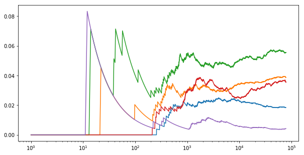

```python
#filename = gluon.utils.download('https://www.gutenberg.org/files/84/84-0.txt')
with open(filename) as f:
    book = f.read()
#print(book[0:100])

book = book.lower()
translator = str.maketrans('', '', string.punctuation)
book = book.translate(translator)
book = book.replace("\n", " ")
book = book.split()
total = len(book)
## Add your codes here
y = np.arange(1,total+1)

def count(wordlist,word):
    x = np.zeros(total)
    for i in range(total):
        if wordlist[i] == word:
            x[i] += 1
            x[i:] = x[i]
    return x/y
a = count(book,'a')
b = count(book,'and')
c = count(book,'the')
d = count(book,'i')
e = count(book,'is')

plt.figure(figsize=(10,5))
for i in [a,b,c,d,e]:
    plt.semilogx(y,i)
plt.show()

#Why can we not apply the Central Limit Theorem directly?
# The occurance of the words are not independent and identically distributed for CLT to apply
```

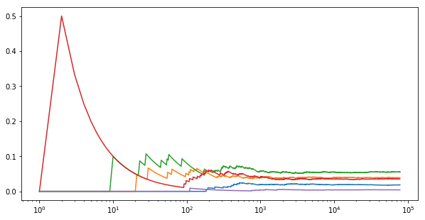

```python
#How would we have to change the text for it to apply?
# Randomdize the word list
random.shuffle(book)
a = count(book,'a')
b = count(book,'and')
c = count(book,'the')
d = count(book,'i')
e = count(book,'is')

plt.figure(figsize=(10,5))
for i in [a,b,c,d,e]:
    plt.semilogx(y,i)
plt.show()

#Why does it still work quite well?
# Disorder the original list, so that the occurance of each word is approximately independent
```

```python
countArray = np.zeros(5)
countArray[0] = book.count("a")
countArray[1] = book.count("and")
countArray[2] = book.count("the")
countArray[3] = book.count("i")
countArray[4] = book.count("is")
print(countArray)
total = len(book)
countArray = countArray/total
char = ["a","and","the","i","is"]
print(char)
print(countArray)
# plt.figure(figsize=(10,5))
# plt.bar(char,countArray)
# plt.show()
```

```
[1439. 3028. 4329. 2766.  330.]
['a', 'and', 'the', 'i', 'is']
[0.01842911 0.03877925 0.05544101 0.03542384 0.00422627]
```

## 3. Denominator-layout notation

We used the numerator-layout notation for matrix calculus in class, now let's examine the denominator-layout notation.

Given $x, y\in\mathbb R$, $\mathbf x\in\mathbb R^n$ and $\mathbf y \in \mathbb R^m$, we have

$$ \frac{\partial y}{\partial \mathbf{x}}=\begin{bmatrix} \frac{\partial y}{\partial x_1}\\ \frac{\partial y}{\partial x_2}\\ \vdots\\ \frac{\partial y}{\partial x_n} \end{bmatrix},\quad \frac{\partial \mathbf y}{\partial {x}}=\begin{bmatrix} \frac{\partial y_1}{\partial x}, \frac{\partial y_2}{\partial x}, \ldots, \frac{\partial y_m}{\partial x} \end{bmatrix} $$

and

$$ \frac{\partial \mathbf y}{\partial \mathbf{x}} =\begin{bmatrix} \frac{\partial \mathbf y}{\partial {x_1}}\\ \frac{\partial \mathbf y}{\partial {x_2}}\\ \vdots\\ \frac{\partial \mathbf y}{\partial {x_3}}\\ \end{bmatrix} =\begin{bmatrix} \frac{\partial y_1}{\partial x_1}, \frac{\partial y_2}{\partial x_1}, \ldots, \frac{\partial y_m}{\partial x_1} \\ \frac{\partial y_1}{\partial x_2}, \frac{\partial y_2}{\partial x_2}, \ldots, \frac{\partial y_m}{\partial x_2}\\ \vdots\\ \frac{\partial y_1}{\partial x_n}, \frac{\partial y_2}{\partial x_n}, \ldots, \frac{\partial y_m}{\partial x_n} \end{bmatrix} $$

Questions:

1. Assume $\mathbf y = f(\mathbf u)$ and $\mathbf u = g(\mathbf x)$, write down the chain rule for $\frac {\partial\mathbf y}{\partial\mathbf x}$
2. Given $\mathbf X \in \mathbb R^{m\times n},\ \mathbf w \in \mathbb R^n, \ \mathbf y \in \mathbb R^m$, assume $z = \| \mathbf X \mathbf w - \mathbf y\|^2$, compute $\frac{\partial z}{\partial\mathbf w}$.

## 4. Numerical Precision

Given scalars `x` and `y`, implement the following `log_exp` function such that it returns a numerically stable version of $$-\log\left(\frac{e^x}{e^x+e^y}\right)$$

```python
def log_exp(x, y):
    ## add your solution here
    return -nd.log(np.e**x/(np.e**x+np.e**y))
```

Test your codes with normal inputs:

```python
x, y = nd.array([2]), nd.array([3])
z = log_exp(x, y)
z
```

```
[1.3132616]
<NDArray 1 @cpu(0)>
```

Now implement a function to compute $\partial z/\partial x$ and $\partial z/\partial y$ with `autograd`

```python
def grad(forward_func, x, y):
    ## Add your codes here
    x.attach_grad()
    y.attach_grad()
    with autograd.record():
        z = forward_func(x,y)
    z.backward()
    print('x.grad =', x.grad)
    print('y.grad =', y.grad)
```

Test your codes, it should print the results nicely.

```python
grad(log_exp, x, y)
```

```
x.grad =
[-0.7310586]
<NDArray 1 @cpu(0)>
y.grad =
[0.7310586]
<NDArray 1 @cpu(0)>
```

But now let's try some "hard" inputs

```python
x, y = nd.array([50]), nd.array([100])
grad(log_exp, x, y)
```

```
x.grad =
[nan]
<NDArray 1 @cpu(0)>
y.grad =
[nan]
<NDArray 1 @cpu(0)>
```

Does your code return correct results? If not, try to understand the reason. (Hint, evaluate `exp(100)`). Now develop a new function `stable_log_exp` that is identical to `log_exp` in math, but returns a more numerical stable result.

```python
def stable_log_exp(x, y):
    return nd.log(1+np.e**(y-x))
grad(stable_log_exp, x, y)
```

```
x.grad =
[-0.9999999]
<NDArray 1 @cpu(0)>
y.grad =
[0.9999999]
<NDArray 1 @cpu(0)>
```